BACK TO PORTFOLIO

# MBTI forum post analysis with gensim tf-idf

While I was looking for potential toy datasets to begin a product feature development for my current OPTiMAL staffing product at TheAIWorks, I ran into this interesting MBTI forum post dataset on Kaggle that gathered over 8600 rows of users with 50 most recent posts per user. One aspect of personality I was always interested in was if personality was "observable" through text.

The Kaggle dataset can be found [here](https://www.kaggle.com/datasnaek/mbti-type).

[figure not shown]

Despite this dataset being slightly biased to begin with due to the source being a personality forum where people are more likely to talk about their personality than other forms of text (Twitter, Facebook, Slack, email...etc.), it is still an interesting case study to see how different personalities communicate.

## PART 1: Cleaning

We begin with the dirty work of cleaning the data:

```python
import numpy as np
import pandas as pd
import seaborn as sns
import re
import collections
import matplotlib.pyplot as plt
```

```python
raw_input = pd.read_csv("mbti_1.csv")
```

First, we take a look at how the dataset is laid out. As we can see via the first 5 rows of the dataset, the MBTI personality type is referenced with the 4 letter representation, with each row representing one user. The user's 50 most recent posts are separated by '|||', making it easy for us to later separate each individual post.

For convenience, we'll be labelling the types by:

Introversion (I) vs. Extraversion (E), Sensing (S) vs. Intuition (N), Thinking (T) vs. Feeling (F), and Judging (J) vs. Perceiving (P).

This will smooth the process of sorting the personality types with boolean labels.

```python
raw_input.head()
```

|  | type | posts |
| --- | --- | --- |
| 0 | INFJ | 'http://www.youtube.com/watch?v=qsXHcwe3krw\|\|\|... |
| 1 | ENTP | 'I'm finding the lack of me in these posts ver... |
| 2 | INTP | 'Good one _____ https://www.youtube.com/wat... |
| 3 | INTJ | 'Dear INTP, I enjoyed our conversation the o... |
| 4 | ENTJ | 'You're fired.\|\|\|That's another silly misconce... |

```python
i_type = raw_input.type.str.contains("I")
n_type = raw_input.type.str.contains("N")
f_type = raw_input.type.str.contains("F")
j_type = raw_input.type.str.contains("J")

type_sorted = raw_input.join(pd.DataFrame(np.transpose([i_type,n_type,f_type,j_type]),
                                          columns=['i_type','n_type','f_type','j_type']))
```

Next, we split each post and observe the post contents by looking at the first 5 posts by the first user:

```python
ind_post = []
for posts in raw_input.posts:
    splitted_posts = re.split("\|\|\|", posts)
    ind_post.append(splitted_posts)
```

From the post, it seems like we will be processing some links that contains numbers and punctuation. Thanks to gensim's preprocessing functions, this should be a quick and easy fix.

```python
ind_post[0][0:5]
```

```
["'http://www.youtube.com/watch?v=qsXHcwe3krw",
 'http://41.media.tumblr.com/tumblr_lfouy03PMA1qa1rooo1_500.jpg',
 'enfp and intj moments  https://www.youtube.com/watch?v=iz7lE1g4XM4  sportscenter not top ten plays  https://www.youtube.com/watch?v=uCdfze1etec  pranks',
 'What has been the most life-changing experience in your life?',
 'http://www.youtube.com/watch?v=vXZeYwwRDw8   http://www.youtube.com/watch?v=u8ejam5DP3E  On repeat for most of today.']
```

```python
from gensim.parsing.preprocessing import strip_tags, strip_punctuation, strip_numeric, strip_multiple_whitespaces
from gensim.parsing.preprocessing import remove_stopwords, preprocess_string, strip_short

CUSTOM_FILTERS = [lambda x: x.lower(), strip_tags, strip_punctuation, strip_numeric, strip_multiple_whitespaces,
                 remove_stopwords, strip_short]

ind_word = []
for posts in ind_post:
    current_ind = []
    for post in posts:
        words_in_post = preprocess_string(post, CUSTOM_FILTERS)
        current_ind += words_in_post
    ind_word.append(current_ind)
```

After stripping the posts of tags, punctuation, numbers, whitespaces, stopwords and short words (less than 3 letters), we can see that the 'words' that we will be processing looks like below:

```python
ind_word[0][0:10]
```

```
['http',
 'www',
 'youtube',
 'com',
 'watch',
 'qsxhcwekrw',
 'http',
 'media',
 'tumblr',
 'com']
```

## PART 2: Computing values

Before we start with computing tf-idf values of words, let's take the first step of counting the words, aka computing the word frequency in the corpus.

This also provides some interesting insights into what words do people use most often when they post in forums, regardless of their personality type:

```python
cnt = collections.Counter()
for author in ind_word:
    curr_counter = collections.Counter(author)
    cnt += curr_counter

cnt.most_common(10)
```

```
[('like', 69704),
 ('think', 49843),
 ('people', 47903),
 ('know', 36946),
 ('time', 27638),
 ('com', 25860),
 ('feel', 23347),
 ('love', 21144),
 ('good', 20752),
 ('things', 20497)]
```

Next, we begin our task of computing tf-idf values with the ease provided to us via the gensim packages. By building a dictionary with all individual words in our corpus and modelling each document by each user, we obtain a tf-idf model for us to work with.

```python
from gensim.models import TfidfModel
from gensim.corpora import Dictionary

dct = Dictionary(ind_word)
```

```python
corpus = [dct.doc2bow(author) for author in ind_word]
model = TfidfModel(corpus)
```

```python
vector = model[corpus[0]]
vector.sort(key=lambda tup: tup[1], reverse = True)
```

```python
simple_topic = []
for score in vector:
    score_word = dct.get(score[0])
    score_num = score[1]

    simple_topic.append([score_word, score_num])
```

Before we start looking into tf-idf values of groups categorised by personality, let's take a quick peek at the td-idf values on the document, or user level. Here we can see the first user in our dataset, with MBTI personality INFJ, has 'banned' as their highest tf-idf value word, due to the uncommon usage amongst all post but how common this user mentioned the word.

However, we can also note that the user posts quite a lot of youtube video links via the high tf-idf values of 'http', 'com', 'www', and 'youtube', as well as what looks like video IDs toward the bottom of the list:

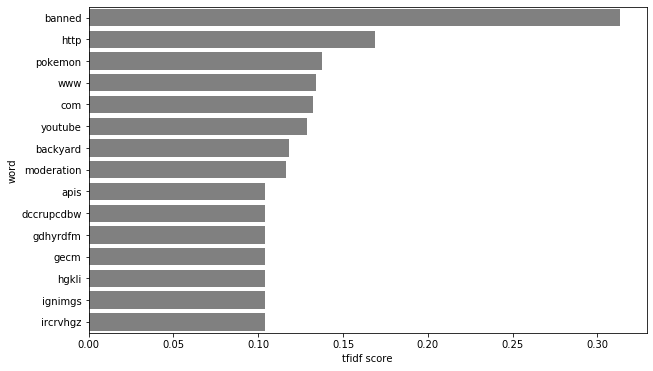

```python
fig = plt.figure(figsize=(10,6))
ax = sns.barplot(x = [x[1] for x in simple_topic[0:15]], y = [x[0] for x in simple_topic[0:15]], color = 'grey')
ax.set_xlabel('tfidf score')
ax.set_ylabel('word')
```

## PART 3: Categorised Analysis

In order to start analysing our computed values by personality grouping, we will need to compute group-wise tf-idf values. This could be accomplished through summing tf-idf values on the document level, as simply by sorting all tf-idf values will result in emphasis on 'individual topics', not 'group topics'.

For this case study, we will only be looking at Extraversion vs. Introversion, as completing this analysis on all personality types would be rather repetitive (not that it would not be interesting though!).

We will be sorting the summed tf-idf values from the model into a nice DataFrame for us to visualise, with extraversion words and introversion words each filling one DataFrame:

```python
i_corpus = []
for index in type_sorted[i_type == True].index:
    i_corpus += corpus[index]

e_corpus = []
for index in type_sorted[i_type == False].index:
    e_corpus += corpus[index]
```

```python
i_vector = []
for index in type_sorted[i_type == True].index:
    i_corpus = corpus[index]
    i_vector += model[i_corpus]
```

```python
i_simple_topic = []
for score in i_vector:
    score_word = dct.get(score[0])
    score_num = score[1]

    i_simple_topic.append([score_word, score_num])
```

```python
i_topic_df = pd.DataFrame(i_simple_topic, columns = ['word','tfidf'])
i_topic_unique = i_topic_df.groupby(['word']).sum().sort_values(by = 'tfidf', ascending = False)
i_topic_unique = i_topic_unique.reset_index()
```

```python
i_count = []
for x in i_topic_unique.word:
    i_count.append(cnt.get(x))

i_topic_unique = i_topic_unique.join(pd.DataFrame(i_count, columns = ['word_count']))
```

```python
e_vector = []
for index in type_sorted[i_type == False].index:
    e_corpus = corpus[index]
    e_vector += model[e_corpus]

e_simple_topic = []
for score in e_vector:
    score_word = dct.get(score[0])
    score_num = score[1]

    e_simple_topic.append([score_word, score_num])

e_topic_df = pd.DataFrame(e_simple_topic, columns = ['word','tfidf'])
e_topic_unique = e_topic_df.groupby(['word']).sum().sort_values(by = 'tfidf', ascending = False)
e_topic_unique = e_topic_unique.reset_index()
```

By including the total word count of the words used in each personality group, we will get to see how tf-idf values compare to simple word frequency. We will be referring back to the `Counter()` object we created during Part 2 for the word count:

```python
e_count = []
for x in e_topic_unique.word:
    e_count.append(cnt.get(x))

e_topic_unique = e_topic_unique.join(pd.DataFrame(e_count, columns = ['word_count']))
```

```python
e_topic_unique
```

|  | word | tfidf | word_count |
| --- | --- | --- | --- |
| 0 | entp | 59.076677 | 7498 |
| 1 | enfp | 58.105077 | 8816 |
| 2 | entj | 36.849012 | 4277 |
| 3 | enfj | 33.461340 | 4315 |
| 4 | lol | 32.589279 | 8889 |
| ... | ... | ... | ... |
| 53046 | humored | 0.024690 | 6 |
| 53047 | chell | 0.024404 | 6 |
| 53048 | rumplestiltskin | 0.023807 | 7 |
| 53049 | glados | 0.023303 | 8 |
| 53050 | atom | 0.022924 | 22 |

53051 rows × 3 columns

We can visualise the information above with a nice bar graph by tf-idf values, using the word frequency as the color for enriching the visualisation with information. We can notice a couple of things from our first visualisation attempt:

1. Introverted posts contain more links like jpg or youtube links compared to extroverted posts
2. Both introverted and extroverted posts contain a lot of reference to their personality types, due to the data source being from a personality forum
3. The introverted group has a higher tf-idf value sum compared to the extroverted group, which may be due to a dataset imbalance (more introverted users than extroverted ones); we will need to verify this later
4. We can spot some overlapping common words that are used by both groups such as `'lol'` and `'welcome'`, as they are common words in any forum under any context, but we can also spot group-unique words such as `'music'`. This does not indicate that extroverts never talk about music on a personality forum, just that they might do it less compared to introverted individuals.
5. Words like `'http'` and `'com'` act like stop words in our case, as they do not hold additional information other than that the users posted a link. As the links are segmented in our case, they hold very little value in our analysis

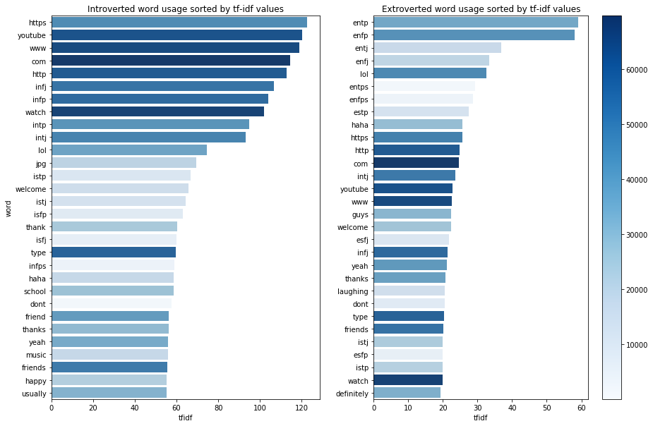

```python
norm = plt.Normalize(min(i_topic_unique.word_count.min(), e_topic_unique.word_count.min()),
                     max(i_topic_unique.word_count.max(), e_topic_unique.word_count.max()))
sm = plt.cm.ScalarMappable(cmap="Blues", norm=norm)
sm.set_array([])

fig = plt.figure(figsize=(15,10))
fig.add_subplot(1,2,1)
i_plot = sns.barplot(data = i_topic_unique[0:30], x = 'tfidf', y = 'word', hue = 'word_count', palette="Blues",
                     dodge=False)
i_plot.legend_.remove()
i_plot.set_title('Introverted word usage sorted by tf-idf values')

fig.add_subplot(1,2,2)
e_plot = sns.barplot(data = e_topic_unique[0:30], x = 'tfidf', y = 'word', hue = 'word_count', palette="Blues",
                     dodge=False)
e_plot.legend_.remove()
e_plot.set_ylabel('')
e_plot.set_title('Extroverted word usage sorted by tf-idf values')
fig.colorbar(sm)
```

Let's verify our assumption about the dataset imbalance:

As we observe here, there is indeed a big imbalance between the number of extroverts vs. the number of introverts in the dataset. While this imbalance could be pose a problem in predictive tasks and be mitigated via resampling tools, for our analysis, it is beneficial to keep it simple as it is as what we're emphasising on are the rankings and proportions.

```python
print( 'Introverted users: ' , len(type_sorted[i_type == True]) , ', Extroverted users: ' ,
      len(type_sorted[i_type == False]))
```

```
Introverted users:  6676 , Extroverted users:  1999
```

Next, we try to address the issues we encountered during our first visualisation attempt:

- abundance of personality profile references
- additional stop words such as `'http'` and `'com'`

We will need a different approach for the two issues, as personality profile references sometimes appear in different forms such as plurals `'entps'` for `'entp'`. This means partial match for these personality profiles will need to be included for removal. In contrast, `'com'` needs exact matching, as partial-matching `'com'` could easily take out words such as `'compassion'` or `'compass'`, which are important words with context in our analysis.

```python
personality_filter = ['intp','intj','infp','infj','istp','isfp','istj','isfj',
              'entp','entj','enfp','enfj','estp','esfp','estj','esfj']

stop_word_additionals = ['http','www','com','https']
```

```python
e_drop_index = []
i_drop_index = []

for wf in personality_filter:
    for index in range(len(e_topic_unique)):
        word = e_topic_unique.word[index]
        if re.match(wf,word) != None:
            e_drop_index += [index]
    for index in range(len(i_topic_unique)):
        word = i_topic_unique.word[index]
        if re.match(wf,word) != None:
            i_drop_index += [index]
```

Before we remove the personality references from our list of forum words by personality group, let's look at what they contain:

As we anticipated, the personality references not only have plural forms, but also adjective forms such as `'intjness'` and `'infpish'`. While this can be an interesting topic of analysis on it's own, our focus for this case study is on common word usage, so we will be removing these words for the time being.

```python
for x in e_topic_unique.word[e_drop_index]:
    print(x)
```

```
intp
intps
intpness
intpforum
intpf
intpsuck
intpfemme
intpee
intj
intjs
intj´s
intjforum
intjellectual
intj’s
intjf
intjish
intjness
infp
infps
infpish
infp’s
infpnerdgirl
infpxintj
infpgiftncurse
infpfantasy
infj
infjs
infjennifer
infj…just
infjlady
infjlove
infjbro
infj´s
istp
istps
istp´s
isfp
isfps
isfpish
istj
```

[output cut: 58 more lines]

```
estp
estps
estpstype
estpsin
estpish
estppreference
esfp
esfps
esfplolitslieksooooobviouslerl
esfpness
esfpproblems
estj
estjs
esfj
esfjs
```

```python
e_topic_unique_filtered = e_topic_unique.drop(e_drop_index)
e_topic_unique_filtered = e_topic_unique_filtered.reset_index()
i_topic_unique_filtered = i_topic_unique.drop(i_drop_index)
i_topic_unique_filtered = i_topic_unique_filtered.reset_index()
```

```python
e_topic_unique_filtered = e_topic_unique_filtered.drop(
    list(np.where(e_topic_unique_filtered.word.isin(stop_word_additionals) == True)[0]))

i_topic_unique_filtered = i_topic_unique_filtered.drop(
    list(np.where(i_topic_unique_filtered.word.isin(stop_word_additionals) == True)[0]))
```

With our second attempt to visualising word usage by introversion vs. extraversion in forum posts, we arrive at our bar plot below. While it is interesting to see the ranking differences of words used between introverts and extroverts, we also start to see that a lot of words are used by both groups.

In order to better illustrate the similarities and differences, we need to find another way to visualise these words:

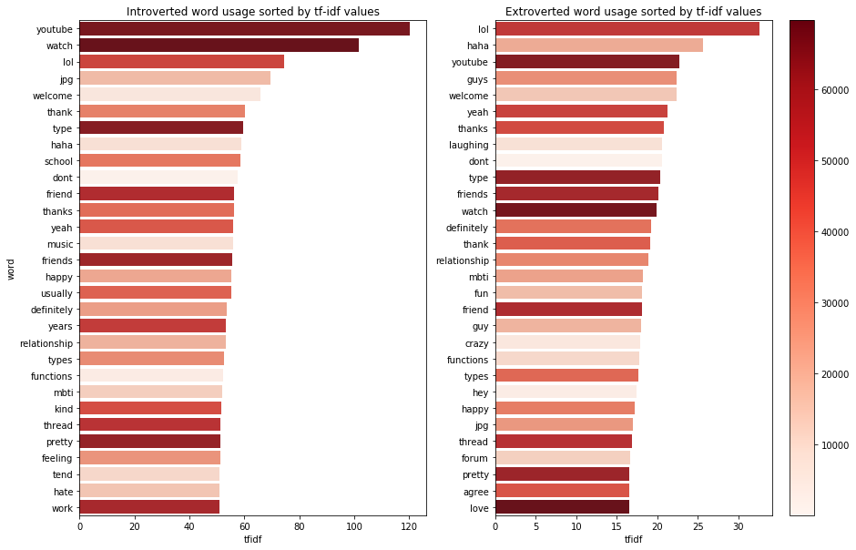

```python
norm = plt.Normalize(min(i_topic_unique_filtered.word_count.min(), e_topic_unique_filtered.word_count.min()),
                     max(i_topic_unique_filtered.word_count.max(), e_topic_unique_filtered.word_count.max()))
sm = plt.cm.ScalarMappable(cmap="Reds", norm=norm)
sm.set_array([])

fig = plt.figure(figsize=(15,10))
fig.add_subplot(1,2,1)
i_plot = sns.barplot(data = i_topic_unique_filtered[0:30], x = 'tfidf', y = 'word',
                     hue = 'word_count', palette="Reds",dodge=False)
i_plot.legend_.remove()
i_plot.set_title('Introverted word usage sorted by tf-idf values')

fig.add_subplot(1,2,2)
e_plot = sns.barplot(data = e_topic_unique_filtered[0:30], x = 'tfidf', y = 'word',
                     hue = 'word_count', palette="Reds",dodge=False)
e_plot.legend_.remove()
e_plot.set_ylabel('')
e_plot.set_title('Extroverted word usage sorted by tf-idf values')
fig.colorbar(sm)
```

And the perfect solution seems to be a word cloud venn diagram! By using the handy wordcloud venn package provided by paulbrodersen [(try it out here!)](https://github.com/paulbrodersen/matplotlib_venn_wordcloud), We could easily see the unique words for each group in the top 100 words used by introverts and extroverts on the personality forum.

While most words are used by both groups, some unique words seem quite fitting given the personality type, such as:

- `'problem'` and `'feeling'` for introverts, as introverts are more reflective and think before they do
- more "exciting" words such as `'crazy'` and `'awesome'` for extroverts, as these words are relatively attention grabbing
- `'music'` for introverts, as enjoying music is more often an individual activity than a group activity
- `'sex'` for extroverts, as extroverts might feel more comfortable sharing a private activity with strangers online than introverts who are less outgoing

While these observations are speculations based on words observed in each personality group based on tf-idf alone, and subjected to the limitation of the dataset and data source, it is still an interesting case study to showcase what insights and information simple text processing can provide us with.

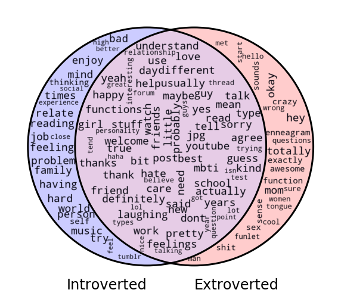

```python
from matplotlib_venn_wordcloud import venn2_wordcloud

fig, ax = plt.subplots(figsize=(10,10))
v = venn2_wordcloud([set(i_topic_unique_filtered.word[0:100]), set(e_topic_unique_filtered.word[0:100])],
                    ax=ax, set_labels=['Introverted','Extroverted'])
# add color
v.get_patch_by_id('10').set_color('blue')
v.get_patch_by_id('10').set_alpha(0.2)
v.get_patch_by_id('01').set_color('red')
v.get_patch_by_id('01').set_alpha(0.2)
v.get_patch_by_id('11').set_color('purple')
v.get_patch_by_id('11').set_alpha(0.2)
```